# Regresión y Correlación Ejemplos

```r
library(tidyverse)
```

**Ejemplo** Dean Parmalee wished to know if the year-end grades assigned to Wright State University Medical School students are predictive of their second-year board scores. The following table shows, for 89 students, the year-end score (AVG, in percent of 100) and the score on the second-year medical board examination (BOARD). Table in REV_C09_17.csv. Perform a complete regression analysis with AVG as the independent variable. Let α = .05 for all tests.  
*Respuesta* Describir los datos. Correr el modelo lineal para Board ~ AVG con $\alpha = 0.05$.

```r
Scores <- read_csv("DataSets/ch09_all/REV_C09_17.csv", show_col_types = FALSE)
Scores
```

```
# A tibble: 89 × 2
     AVG BOARD
   <dbl> <dbl>
 1  95.7   257
 2  94.0   256
 3  91.5   242
 4  91.5   223
 5  91.1   241
 6  90.9   234
 7  90.8   226
 8  90.6   236
 9  90.3   250
10  90.3   226
# … with 79 more rows
```

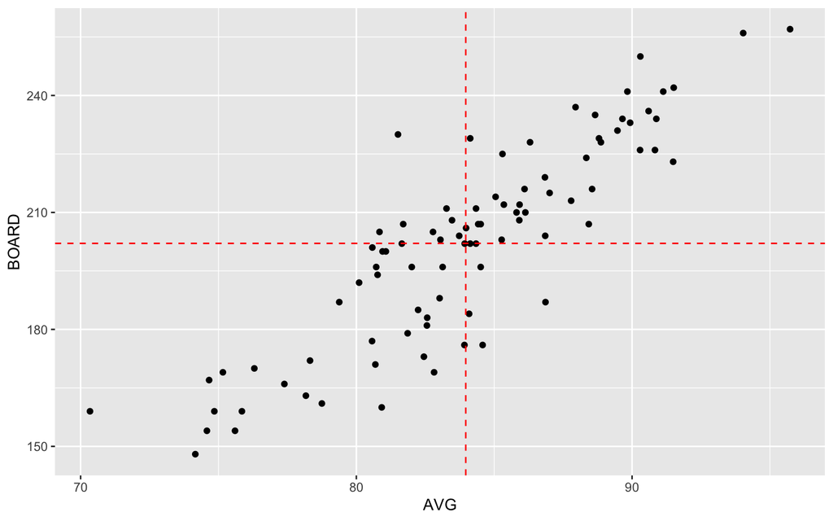

```r
ggplot(Scores, aes(x = AVG, y = BOARD)) +
  geom_point() +
  geom_hline(aes(yintercept = mean(BOARD)), linetype = "dashed", color = "red") +
  geom_vline(aes(xintercept = mean(AVG)), linetype = "dashed", color = "red")
```

```r
Scores_lm <- lm(BOARD ~ AVG, data = Scores)
summary(Scores_lm)
```

```
Call:
lm(formula = BOARD ~ AVG, data = Scores)

Residuals:
    Min      1Q  Median      3Q     Max
-28.931  -8.150   2.397   7.193  39.441

Coefficients:
             Estimate Std. Error t value Pr(>|t|)
(Intercept) -191.0296    22.9342  -8.329 1.06e-12 ***
AVG            4.6815     0.2727  17.169  < 2e-16 ***
---
Signif. codes:  0 '***' 0.001 '**' 0.01 '*' 0.05 '.' 0.1 ' ' 1

Residual standard error: 12.49 on 87 degrees of freedom
Multiple R-squared:  0.7721,    Adjusted R-squared:  0.7695
F-statistic: 294.8 on 1 and 87 DF,  p-value: < 2.2e-16
```

```r
confint(Scores_lm)
```

```
                  2.5 %      97.5 %
(Intercept) -236.613708 -145.445446
AVG            4.139525    5.223459
```

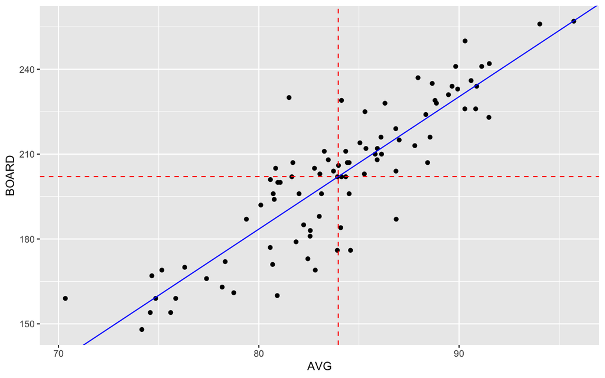

```r
ggplot(Scores, aes(x = AVG, y = BOARD)) +
  geom_point() +
  geom_hline(aes(yintercept = mean(BOARD)), linetype = "dashed", color = "red") +
  geom_vline(aes(xintercept = mean(AVG)), linetype = "dashed", color = "red") +
  geom_abline(aes(intercept = Scores_lm$coefficients[1], slope = Scores_lm$coefficients[2]), color = "blue")
```

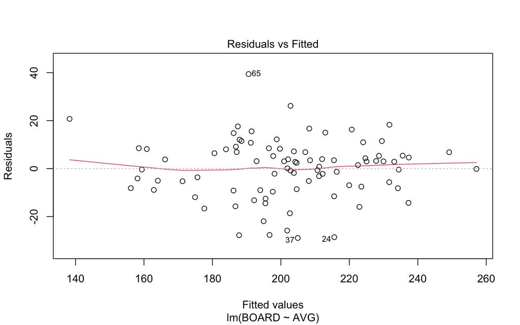

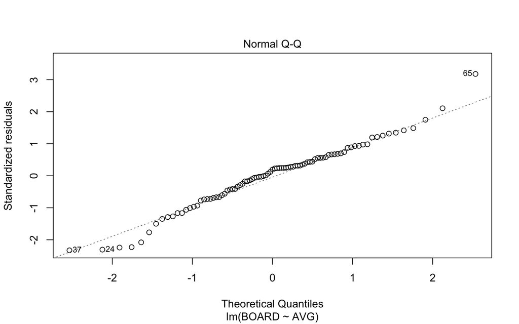

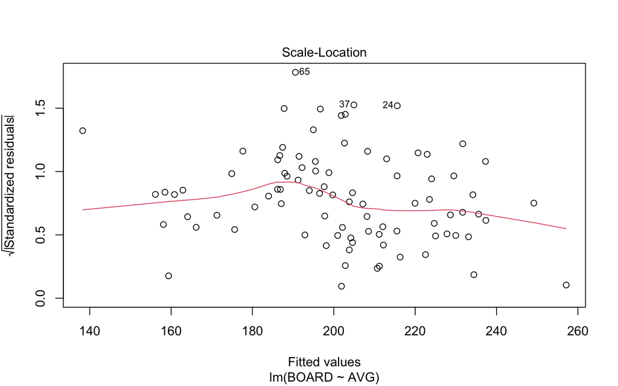

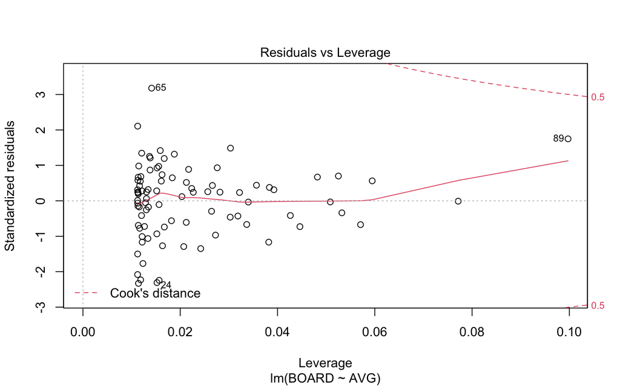

```r
plot(Scores_lm)
```

*Respuesta* Vamos a estimar el modelo lineal `lm` para determinar que podemos desechar la hipótesis nula $H_0 : \beta_2 = 0$, es decir $H_a : \beta_2 \ne 0$ es decir que si existe el modelo y la pendiente $\beta_2$ es diferente de cero. Para hacer la prueba de hipótesis de $\rho$ estimaremos la prueba de correlación a un nivel del .05.

```r
Temp <- read_csv("DataSets/ch09_all/REV_C09_25.csv", show_col_types = FALSE)
Temp
```

```
# A tibble: 10 × 2
    TIME  TEMP
   <dbl> <dbl>
 1    24  38.8
 2    28  39.5
 3    32  40.3
 4    36  40.7
 5    40  41
 6    44  41.1
 7    48  41.4
 8    52  41.6
 9    56  41.8
10    60  41.9
```

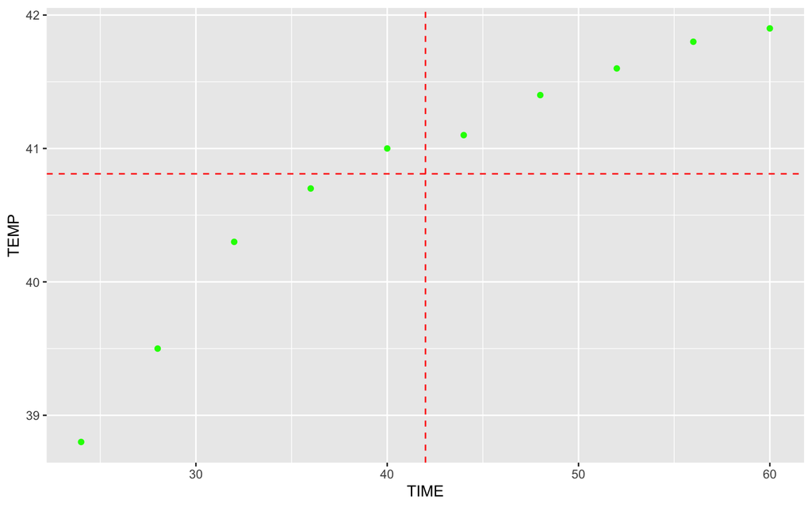

```r
ggplot(Temp, aes(x = TIME, y = TEMP)) +
  geom_point(color = "green") +
  geom_hline(aes(yintercept = mean(TEMP)), linetype = "dashed", color = "red") +
  geom_vline(aes(xintercept = mean(TIME)), linetype = "dashed", color = "red")
```

```r
Temp_lm <- lm(TEMP ~ TIME, data = Temp)
summary(Temp_lm)
```

```
Call:
lm(formula = TEMP ~ TIME, data = Temp)

Residuals:
     Min       1Q   Median       3Q      Max
-0.57273 -0.17606  0.05121  0.24894  0.36909

Coefficients:
             Estimate Std. Error t value Pr(>|t|)
(Intercept) 37.456364   0.395901  94.610 1.74e-13 ***
TIME         0.079848   0.009092   8.782 2.22e-05 ***
---
Signif. codes:  0 '***' 0.001 '**' 0.01 '*' 0.05 '.' 0.1 ' ' 1

Residual standard error: 0.3303 on 8 degrees of freedom
Multiple R-squared:  0.906, Adjusted R-squared:  0.8943
F-statistic: 77.13 on 1 and 8 DF,  p-value: 2.218e-05
```

```r
# Para estimar los intervalos de confianza de los parámetros estimados del modelo
confint(Temp_lm, level = 0.95)
```

```
                 2.5 %     97.5 %
(Intercept) 36.5434139 38.3693134
TIME         0.0588819  0.1008151
```

```r
# Para estimar una respuesta del modelo en un punto dado, TIME 50 hrs, y su intervalo de confianza al 95%
new_TIME <- data.frame(TIME = 50)
predict(Temp_lm, newdata = new_TIME, interval = "confidence", level = 0.95)
```

```
       fit      lwr      upr
1 41.44879 41.15526 41.74232
```

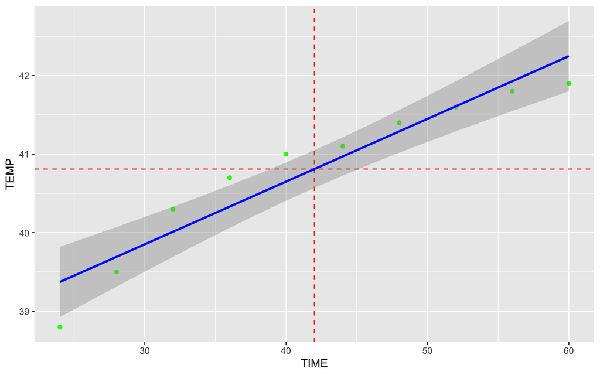

```r
ggplot(Temp, aes(x = TIME, y = TEMP)) +
  geom_point(color = "green") +
  geom_hline(aes(yintercept = mean(TEMP)), linetype = "dashed", color = "red") +
  geom_vline(aes(xintercept = mean(TIME)), linetype = "dashed", color = "red") +
  geom_smooth(method = lm, color = "blue")
```

```r
# test Ho : rho = 0 and construct a 95% confidence interval for rho.
cor.test(Temp$TIME, Temp$TEMP, level = .95)
```

```
    Pearson's product-moment correlation

data:  Temp$TIME and Temp$TEMP
t = 8.7821, df = 8, p-value = 2.218e-05
alternative hypothesis: true correlation is not equal to 0
95 percent confidence interval:
 0.8041770 0.9888496
sample estimates:
      cor
0.9518514
```

**Ejemplo** Reiss et al. compared point-of-care and standard hospital laboratory assays for monitoring patients receiving a single anticoagulant or a regimen consisting of a combination of anticoagulants. It is quite common when comparing two measuring techniques, to use regression analysis in which one variable is used to predict another. In the present study, the researchers obtained measures of international normalized ratio (INR) by assay of capillary and venous blood samples collected from 90 subjects taking warfarin. INR, used especially when patients are receiving warfarin, measures the clotting ability of the blood. Point-of-care testing for INR was conducted with the CoaguChek assay product. Hospital testing was done with standard hospital laboratory assays. The authors used the hospital assay INR level to predict the CoaguChek INR level. The measurements are given in EXR_C09_S03_04.csv.

*Respuesta* Nos piden desarrollar un modelo lineal para probar las medidas de CoaguCheck (variable respuesta) en función de las medidas del laboratorio del hospital (predictores para INR). Y probar si podemos desechar la hipótesis nula $H_0 : \beta_2 =0$ para el modelo `Y(CoaguCheck) ~ X(Hospital)`. Estimaremos los parámetros del modelo y calcularemos los intervalos de confianza al 95% de los parámetros estimados. La gráfica del modelo lineal incluye el intervalo de error del modelo ajustado.

```r
INR <- read_csv("DataSets/ch09_all/EXR_C09_S03_04.csv", show_col_types = FALSE)
INR
```

```
# A tibble: 90 × 2
       Y     X
   <dbl> <dbl>
 1   1.8   1.6
 2   1.6   1.9
 3   2.5   2.8
 4   1.9   2.4
 5   1.3   1.5
 6   2.3   1.8
 7   1.2   1.3
 8   2.3   2.4
 9   2     2.1
10   1.5   1.5
# … with 80 more rows
```

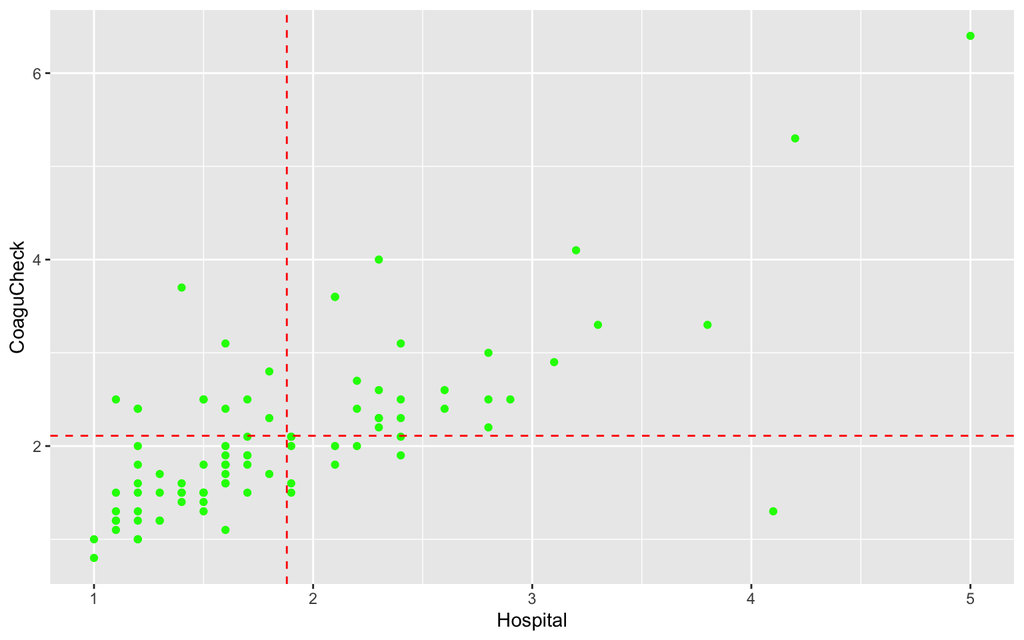

```r
INR <- INR %>%
  rename( CoaguCheck = Y, Hospital = X)

ggplot(INR, aes(x = Hospital, y = CoaguCheck)) +
  geom_point(color = "green") +
  geom_hline(aes(yintercept = mean(CoaguCheck)), linetype = "dashed", color = "red") +
  geom_vline(aes(xintercept = mean(Hospital)), linetype = "dashed", color = "red")
```

```r
INR_lm <- lm(CoaguCheck ~ Hospital, data = INR)
summary(INR_lm)
```

```
Call:
lm(formula = CoaguCheck ~ Hospital, data = INR)

Residuals:
    Min      1Q  Median      3Q     Max
-2.7248 -0.3357 -0.1341  0.1306  2.0040

Coefficients:
            Estimate Std. Error t value Pr(>|t|)
(Intercept)  0.48848    0.18167   2.689  0.00858 **
Hospital     0.86251    0.08972   9.613 2.24e-15 ***
---
Signif. codes:  0 '***' 0.001 '**' 0.01 '*' 0.05 '.' 0.1 ' ' 1

Residual standard error: 0.64 on 88 degrees of freedom
Multiple R-squared:  0.5122,    Adjusted R-squared:  0.5067
F-statistic: 92.41 on 1 and 88 DF,  p-value: 2.244e-15
```

```r
confint(INR_lm, level = 0.95)
```

```
                2.5 %    97.5 %
(Intercept) 0.1274485 0.8495109
Hospital    0.6842054 1.0408162
```

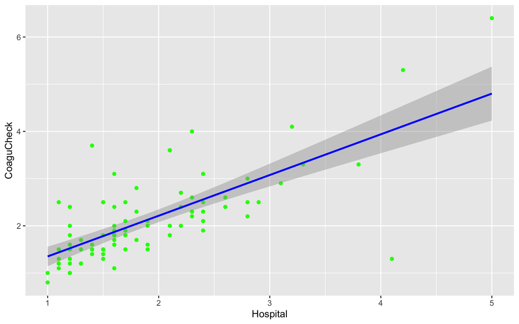

```r
ggplot(INR, aes(x = Hospital, y = CoaguCheck)) +
  geom_point(color = "green") +
  geom_smooth(method = lm, color = "blue")
```

**Ejemplo**Another variable of interest in the study by Reiss et al. (see last example) was partial thromboplastin (aPTT), the standard test used to monitor heparin anticoagulation. Use the data in the following table to examine the correlation between aPTT levels as measured by the CoaguCheck point-of-care assay and standard laboratory hospital assay in 90 subjects receiving heparin alone, heparin with warfarin, and warfarin and exoenoxaparin table EXR_C09_S07_02.csv.  
*Respuesta* Para probar si es posible desechar la hipótesis nula $H_0 : \rho = 0$ se corre la prueba de correlación de los datos de aPTT.

```r
aPTT <- read_csv("DataSets/ch09_all/EXR_C09_S07_02.csv", show_col_types = FALSE)
aPTT
```

```
# A tibble: 90 × 2
   COAGU  HOSP
   <dbl> <dbl>
 1  49.3  71.4
 2  57.9  86.4
 3  59    75.6
 4  77.3  54.5
 5  42.3  57.7
 6  44.3  59.5
 7  90    77.2
 8  55.4  63.3
 9  20.3  27.6
10  28.7  52.6
# … with 80 more rows
```

```r
cor.test(aPTT$HOSP, aPTT$COAGU, method = "pearson", conf.level = 0.95)
```

```
    Pearson's product-moment correlation

data:  aPTT$HOSP and aPTT$COAGU
t = 10.17, df = 88, p-value < 2.2e-16
alternative hypothesis: true correlation is not equal to 0
95 percent confidence interval:
 0.6227350 0.8176615
sample estimates:
     cor
0.735034
```